# GST expenditure by age and income, for categories

Hugh Parsonage

# What are the consumption patterns of different income quintiles?

This `Rmd` file attempts to determine the distributional impact of broadening the GST to include currently exempt food, education, health, and childcare. We use the ABS’s Household Expenditure Survey 2009-10, being the most recent survey containing this information.

Some issues:

- No behaviour change. We assume there will be no change (*i.e.* no reduction) in consumption of items currently GST exempt.
- Health expenditure is dubious. Highly volatile spending.
- Fresh food is available for each quintile. We assume the relationship between spending on GST-exempt food and income is linear and does not change across age groups.
- Education spending not availble except aggregated by household income and household age head of household. We assume that the relationship between spending and income is the same across each age group.
- Education and childcare spending only available by quintile. We assume that half the total spending in a quintile goes to each decile.

```r
knitr::opts_chunk$set(warning = FALSE,
                      message = FALSE,
                      cache=TRUE,
                      fig.height=8, fig.width=10)
```

```r
library(ggplot2)
library(scales)
library(grattan)
library(VIM) # VIM::hotdeck used for imputation
library(dplyr)
library(foreign)
library(survey)
library(data.table)
library(readxl)
library(readr)
library(tidyr)
library(magrittr)
library(httr)

weighted.var.se <- function(x, w, na.rm=FALSE){
  # Computes the variance of a weighted mean following Cochran 1977 definition
  # http://stats.stackexchange.com/questions/25895/computing-standard-error-in-weighted-mean-estimation
  if (na.rm) { w <- w[i <- !is.na(x)]; x <- x[i] }
  n = length(w)
  xWbar = weighted.mean(x,w,na.rm=na.rm)
  wbar = mean(w)
  out = n/((n-1)*sum(w)^2)*(sum((w*x-wbar*xWbar)^2)-2*xWbar*sum((w-wbar)*(w*x-wbar*xWbar))+xWbar^2*sum((w-wbar)^2))
  return(out)
}

age_mutate <- function(.hes){
  if("Age_of_HH_reference_person" %in% names(.hes)){
    .hes %>%
      mutate(
        age_group = as.character(Age_of_HH_reference_person),
        age_group = ifelse(grepl("^[0-9]+$", age_group),
                           ifelse(as.numeric(age_group) < 20,
                                  "20 or under",
                                  paste((as.numeric(age_group) %/% 5) * 5,
                                        "to",
                                        (as.numeric(age_group) %/% 5) * 5 + 4)),
                           age_group
        )
      )
  }

  if("Age_of_person" %in% names(.hes)){
    .hes %>%
      mutate(
        age_group = as.character(Age_of_person),
        age_group = ifelse(grepl("^[0-9]+$", age_group),
                           ifelse(as.numeric(age_group) < 20,
                                  "20 or under",
                                  paste((as.numeric(age_group) %/% 5) * 5,
                                        "to",
                                        (as.numeric(age_group) %/% 5) * 5 + 4)),
                           age_group
        )
      )
  }

}

group_by.income_quintile <- function(.data, type = "Total_current_weekly_HH_income_from_all_sources"){
  if(type == "Current_weekly_HH_disposable_income"){
    group_by(.data, income_quintile = factor(as.numeric(cut(Current_weekly_HH_disposable_income,
                                                            breaks = total.inc.quintiles,
                                                            include.lowest = TRUE)))) %>%
      arrange(income_quintile)
  } else {
    if (type == "Total_current_weekly_HH_income_from_all_sources"){
      group_by(.data, income_quintile = factor(as.numeric(cut(Total_current_weekly_HH_income_from_all_sources,
                                                            breaks = total.inc.quintiles,
                                                            include.lowest = TRUE)))) %>%
      arrange(income_quintile)
    }
  }
}


# for asymmetric expansion of limits
scale_dimension.custom_expand <- function(scale, expand = ggplot2:::scale_expand(scale)) {
  expand_range(ggplot2:::scale_limits(scale), expand[[1]], expand[[2]])
}

scale_y_continuous <- function(...) {
  s <- ggplot2::scale_y_continuous(...)
  class(s) <- c('custom_expand', class(s))
  s
}

scale_x_continuous <- function(...) {
  s <- ggplot2::scale_x_continuous(...)
  class(s) <- c('custom_expand', class(s))
  s
}

scale_x_date <- function(...) {
  s <- ggplot2::scale_x_date(...)
  class(s) <- c('custom_expand', class(s))
  s
}

# Taxation statistics 2012-13 Goods and services tax: Selected GST, WET and LCT items, 2001-02 to 2013-14 financial years
if(!file.exists("GST_by_year.xlsx")){
  GST_url <- "http://data.gov.au/dataset/e29ef9ca-0d1a-47ec-9e9b-14a79a941511/resource/0e56ca39-832e-40ca-bc62-297a3fb552cf/download/taxstats2013gst1gstwetlctmultiyear.xlsx"
  GET(GST_url, write_disk("GST_by_year.xlsx"))
}
GST_inflator_from0910_to1314 <-
  read_excel("GST_by_year.xlsx", sheet = "GST Table 1", skip = 2) %>%
  setnames(1:2, c("Selected_item", "unit")) %>%
  # en dash caution
  setnames(old = names(.), new = gsub("([0-9]{4}).([0-9]{2})", "\\1-\\2", names(.))) %>%
  gather(year, value, `2001-02`:`2013-14`) %>%
  mutate(value = as.numeric(value)) %>%
  filter(complete.cases(.)) %>%
  filter(grepl("Net.GST", Selected_item)) %>%
  filter(grepl("^((2009)|(2012)|(2013))", year)) %$%
  {last(value) / first(value)}

GST_inflator_from0910_to1213 <-
  read_excel("GST_by_year.xlsx", sheet = "GST Table 1", skip = 2) %>%
  setnames(1:2, c("Selected_item", "unit")) %>%
  # en dash caution
  setnames(old = names(.), new = gsub("([0-9]{4}).([0-9]{2})", "\\1-\\2", names(.))) %>%
  gather(year, value, `2001-02`:`2013-14`) %>%
  mutate(value = as.numeric(value)) %>%
  filter(complete.cases(.)) %>%
  filter(grepl("Net.GST", Selected_item)) %>%
  filter(grepl("^((2009)|(2012))", year)) %$%
  {last(value) / first(value)}
```

Our first task is to make the HES variables meaningful. Do you know what `INCTOPH8` means? Let’s find out! The way I did that was to link the variables in the variable listings excel file to the definition therein. We also have to make the variables suitable for R, *viz* no spaces or weird characters.

```r
hes10hh_raw <- read.dta("./HES/hes10bh.dta")

hes.sih.vars <- read_excel("./SIH/HES_and_SIH_variable_listing.xlsx")

# See page 21 of HES 2009-10 user guide
# http://www.ausstats.abs.gov.au/ausstats/subscriber.nsf/0/1D03ACBBD40275ADCA257A3900173E85/$File/65030_1.pdf
hes.sih.vars %<>%
  mutate(Definition = ifelse(HES_basic_name == "COICEXP", paste0(Definition, "_COICOP"), Definition))

hes.sih.vars %<>%
  gather(GROUP, variable, -Definition) %>%
  mutate(variable = gsub("[^A-Za-z0-9]", "", variable)) %>%
  filter(complete.cases(.)) %>%
  spread(GROUP, variable) %>%
  mutate(
    # replace all nonletters with _ unless they occur at the end of the name,
    # in which case delete it
    Definition_new = gsub("[^A-Za-z]+(?!$)", "_", Definition, perl = TRUE),
    Definition_new = gsub("[^A-Za-z]+$", "", Definition_new)
  )
```

```r
hes10hh.names <-
  hes.sih.vars$HES_basic_name[hes.sih.vars$HES_basic_name %in% names(hes10hh_raw)]
hes10hh.newnames <-
  hes.sih.vars$Definition_new[hes.sih.vars$HES_basic_name %in% names(hes10hh_raw)]

hes10hh <-
  hes10hh_raw %>%
  # This omits some weights and PETTAX (hh consumption of fuel tax) for some reason
  select_(.dots = hes10hh.names) %>%
  data.table %>%
  setnames(old = hes10hh.names,
           new = hes10hh.newnames)
```

We now have an object, `hes10hh`, with meaningful column names. I prefer the following values for our ages:

```r
# Age cleaning
hes10hh %<>%
  mutate(
    Age_of_HH_reference_person = factor(gsub(" years",
                                             "",
                                             Age_of_HH_reference_person))
  )
```

## Calculation of quantiles.

We will only use the quintiles and deciles.

```r
disp.inc.percentiles <-
  hes10hh %>%
  svydesign(~Unique_household_number, data = ., weights = ~Weight_HH_HES) %>%
  svyquantile(~Current_weekly_HH_disposable_income # disposable income
              ,.
              ,quantiles = c(0:100)/100)
disp.inc.deciles <-
  hes10hh %>%
  svydesign(~Unique_household_number, data = ., weights = ~Weight_HH_HES) %>%
  svyquantile(~Current_weekly_HH_disposable_income
              ,.
              , quantiles = c(0:10)/10)

total.inc.percentiles <-
  hes10hh %>%
  svydesign(~Unique_household_number, data = ., weights = ~Weight_HH_HES) %>%
  svyquantile(~Total_current_weekly_HH_income_from_all_sources
              ,.
              , quantiles = c(0:100)/100)

total.inc.deciles <-
  hes10hh %>%
  svydesign(~Unique_household_number, data = ., weights = ~Weight_HH_HES) %>%
  svyquantile(~Total_current_weekly_HH_income_from_all_sources
              ,.
              , quantiles = c(0:10)/10)

total.inc.quintiles <-
  hes10hh %>%
  svydesign(~Unique_household_number, data = ., weights = ~Weight_HH_HES) %>%
  svyquantile(~Total_current_weekly_HH_income_from_all_sources
              ,.
              #, quantiles = c(0:5)/5)
              ,quantiles = c(0:5)/5)


hes10hh %<>%
  mutate(income.percentile = factor(as.numeric(cut(Current_weekly_HH_employee_income,
                                                   breaks = disp.inc.percentiles,
                                                   include.lowest = TRUE))))
```

```r
hes10hh %>%
  group_by(income.percentile) %>%
  summarise(mean = weighted.mean(Household_weekly_expenditure_on_food_and_non_alcoholic_beverages_HES_only, w = Weight_HH_HES),
            se = sqrt(weighted.var.se(Household_weekly_expenditure_on_food_and_non_alcoholic_beverages_HES_only, w = Weight_HH_HES))) %>%
  arrange(income.percentile)
```

```
## Source: local data table [100 x 3]
##
##    income.percentile      mean       se
##               (fctr)     (dbl)    (dbl)
## 1                  1 131.45488  2.22672
## 2                  2 173.42142 19.05964
## 3                  3 170.66720 13.79774
## 4                  4 179.42195 18.24814
## 5                  5 206.45451 51.79047
## 6                  6 193.73893 38.66543
## 7                  7 165.57587 54.66886
## 8                  8  97.05263 27.52130
## 9                  9 122.33266 39.68321
## 10                10 186.30019 28.83169
## ..               ...       ...      ...
```

```r
food_by_age <-
  hes10hh %>%
  mutate(
    age_group = as.character(Age_of_HH_reference_person),
    age_group = ifelse(grepl("^[0-9]+$", age_group),
                       ifelse(as.numeric(age_group) < 20,
                              "20 or under",
                              paste((as.numeric(age_group) %/% 5) * 5,
                                    "to",
                                    (as.numeric(age_group) %/% 5) * 5 + 4)),
                       age_group
    )
  ) %>%
  mutate(total.inc.deciles = factor(as.numeric(cut(Current_weekly_HH_employee_income,
                                                   breaks = total.inc.deciles,
                                                   include.lowest = TRUE)))) %>%
  svydesign(~Unique_household_number, data = ., weights = ~Weight_HH_HES) %>%
  svyby(~Household_weekly_expenditure_on_food_and_non_alcoholic_beverages_HES_only, ~total.inc.deciles + age_group, ., svymean,
        keep.names = FALSE) %>%
  setnames(c("Total_income_decile",
             "age_group",
             "Food_exp.avg",
             "se")) %>%
  # cosmetic
  setattr(c("call", "svyby"), c(NULL, NULL)) %>%
  mutate(Total_income_decile = as.integer(as.character(Total_income_decile)))
```

## Individuals

```r
hes10_indiv_raw <-
  read.dta("./HES/hes10bp.dta")

hes10hp.names <-
  hes.sih.vars$HES_basic_name[hes.sih.vars$HES_basic_name %in% names(hes10_indiv_raw)]
hes10hp.newnames <-
  hes.sih.vars$Definition_new[hes.sih.vars$HES_basic_name %in% names(hes10_indiv_raw)]

hes10_indiv <-
  hes10_indiv_raw %>%
  data.table %>%
  select_(.dots = hes10hp.names) %>%
  setnames(old = hes10hp.names,
           new = hes10hp.newnames)

total.inc.deciles_indiv <-
  hes10_indiv_raw %>%
  svydesign(~ABSPID, data = ., weights = ~HESPSWT) %>%
  svyquantile(~INCTSCP8 # total weekly income from all sources
              ,.
              , quantiles = c(0:10)/10)

total.inc.quintiles_indiv <-
  hes10_indiv_raw %>%
  svydesign(~ABSPID, data = ., weights = ~HESPSWT) %>%
  svyquantile(~INCTSCP8 # total weekly income from all sources
              ,.
              , quantiles = c(0:5)/5)

# hes10_indiv %>%
#   mutate(tot.inc.deciles = factor(as.numeric(cut(Total_current_weekly_income_from_all_sources,
#                                                   breaks = total.inc.deciles_indiv,
#                                                   include.lowest = TRUE)))) %>%
#   svydesign(~Person_number_within_each_income_unit, data = ., weights = ~Weight_Person_HES) %>%
#   svyby(~Household_weekly_expenditure_on_food_and_non_alcoholic_beverages_HES_only,
#         by = ~tot.inc.deciles + Age_of_person,
#         svymean)
```

```r
HH_GST_expenditure_by_quintile <-
  read_excel("HH_GST_expenditure_by_quintile.xlsx", sheet = "GST_by_quintile") %>%
  gather(Quintile, weekly_expenditure, Q1:Q5) %>%
  filter(!grepl("[12]$", Category))
```

```r
HH_food_expenditure_by_decile.age <-
  hes10hh %>%
  mutate(
    age_group = as.character(Age_of_HH_reference_person),
    age_group = ifelse(grepl("^[0-9]+$", age_group),
                       ifelse(as.numeric(age_group) < 20,
                              "20 or under",
                              paste((as.numeric(age_group) %/% 5) * 5,
                                    "to",
                                    (as.numeric(age_group) %/% 5) * 5 + 4)),
                       age_group
    )
  ) %>%
  mutate(Total_income_decile = factor(as.numeric(cut(Current_weekly_HH_disposable_income,
                                                   breaks = total.inc.deciles,
                                                   include.lowest = TRUE))))
```

## Determining the GST expenditure for each category, for each age and income decile

### Household quintiles

```r
HH_GST_expenditure_by_quintile %<>%
  mutate(
    quantile = as.numeric(gsub("Q", "", Quintile)),
    quantile = (quantile / 5) - 0.1 - (quantile < 3) * 0.05 + (quantile > 3) * 0.05,
    Quintile = as.integer(gsub("Q", "", Quintile))
  )
```

```r
food_and_income.gst <-
  hes10hh %>%
  mutate(total.inc.quintiles = factor(as.numeric(cut(Total_current_weekly_HH_income_from_all_sources,
                                                     breaks = total.inc.quintiles,  # Total current weekly HH income from all sources
                                                     include.lowest = TRUE)))) %>%
  group_by(total.inc.quintiles) %>%
  summarise(
    average_food = weighted.mean(Household_weekly_expenditure_on_food_and_non_alcoholic_beverages_HES_only,
                                 w = Weight_HH_HES)) %>%
  data.frame %>%
  merge(filter(HH_GST_expenditure_by_quintile, Category == "Food"), by.x = "total.inc.quintiles", by.y = "Quintile") %>%
  setnames("weekly_expenditure", "weekly_exp_GST_liable_food") %>%
  mutate(prop = weekly_exp_GST_liable_food/average_food) %>%
  merge(data.frame(quantile = (0:20)/20), all.y = TRUE, all.x = TRUE) %>%
  do(data.frame(., pred_prop_GST = predict(lm(prop ~ quantile, data = .), newdata=.))) %>%
  select(quantile, pred_prop_GST) %>%
  # BEWARE FLOATING POINT ARITHMETIC
  dplyr::filter(quantile %in% c(0.05, 0.15, 0.25, 0.35, 0.45, 0.55, 0.65, 0.75, 0.85, 0.95)) %>%
  mutate(Total_income_decile = as.integer(factor(quantile)))
```

### Food consumption by age

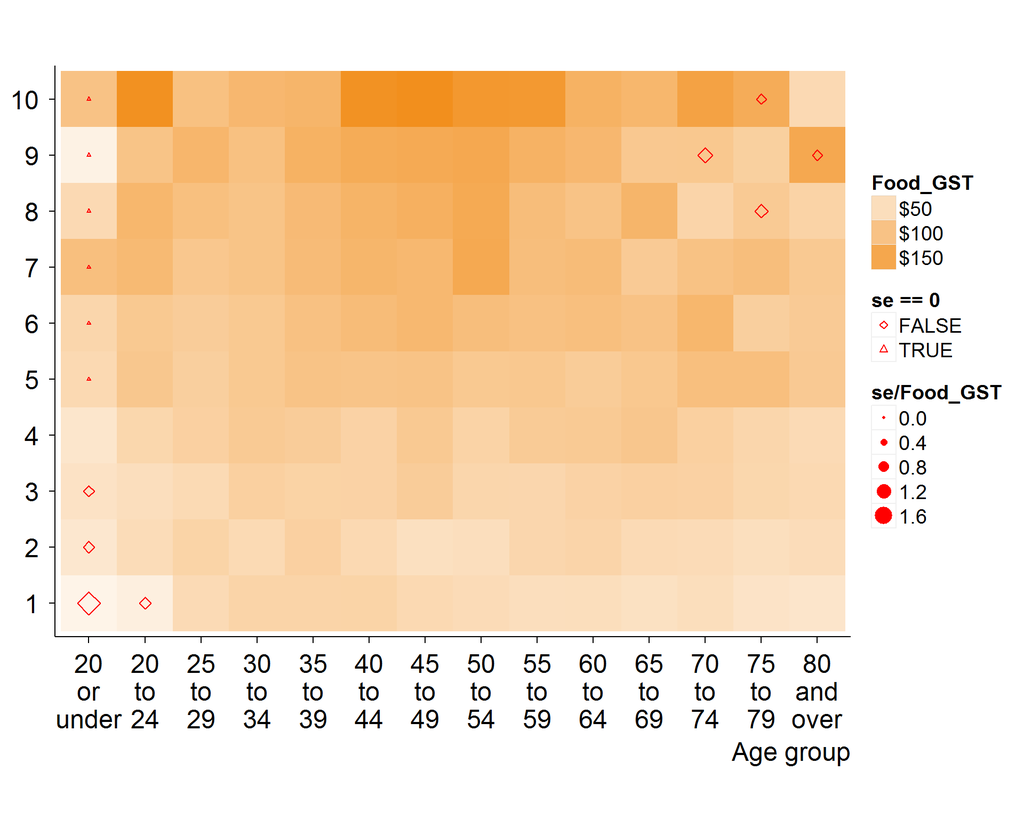

```r
chessboard <-
  data.table::CJ(
    unique(HH_food_expenditure_by_decile.age$age_group),
    1:10
  ) %>%
  setnames(old = paste0("V", 1:2), new = c("age_group", "Total_income_decile"))

food_by_age_income <-
  HH_food_expenditure_by_decile.age %>%
  merge(chessboard, by = c("age_group", "Total_income_decile"), all.y = TRUE) %>%
  ## HOT DECK
  VIM::hotdeck(., variable = "Household_weekly_expenditure_on_food_and_non_alcoholic_beverages_HES_only") %>%
  VIM::hotdeck(., variable = "Household_weekly_expenditure_on_food_and_non_alcoholic_beverages_HES_only") %>%
  # this is to ensure smooth execution of code with following design objects
  mutate(Unique_household_number = ifelse(is.na(Unique_household_number),
                                          paste0(lag(Unique_household_number), "x"),
                                          Unique_household_number),
         Weight_HH_HES = ifelse(is.na(Weight_HH_HES),
                                max(Weight_HH_HES, na.rm = TRUE),
                                Weight_HH_HES)) %>%
  svydesign(~Unique_household_number, data = ., weights = ~Weight_HH_HES) %>%
  svyby(~Household_weekly_expenditure_on_food_and_non_alcoholic_beverages_HES_only, ~Total_income_decile + age_group, ., svymean, keep.names = FALSE) %>%
  setnames(c("Total_income_decile",
             "age_group",
             "Food_exp.avg",
             "se")) %>%
  setattr(c("call", "svyby"), c(NULL, NULL)) %>%
  mutate(Total_income_decile = as.integer(as.character(Total_income_decile))) %>%
  merge(food_and_income.gst, by = "Total_income_decile") %>%
  mutate(Food_GST = Food_exp.avg * pred_prop_GST) %>%
  mutate(age_group_text = gsub("\\s+", "\n", age_group))

food_by_age_income %>%
  grplot(aes(x = age_group_text, y = factor(Total_income_decile), alpha = Food_GST)) +
  geom_tile(fill = Orange) +
  geom_point(data = filter(food_by_age_income, 1.96 * se > Food_GST | se == 0),
             aes(size = se/Food_GST,
                 shape = se == 0),
             color = "red", alpha= 1) +
  scale_alpha_continuous(label=grattan_dollar) +
  xlab("Age group") +
  scale_shape_manual(values = c(23, 24)) +
  coord_equal() +
  theme_grattan(base_size = 18) +
  theme(panel.grid.major.y = element_blank(),
        legend.position = "right")
```

## Health

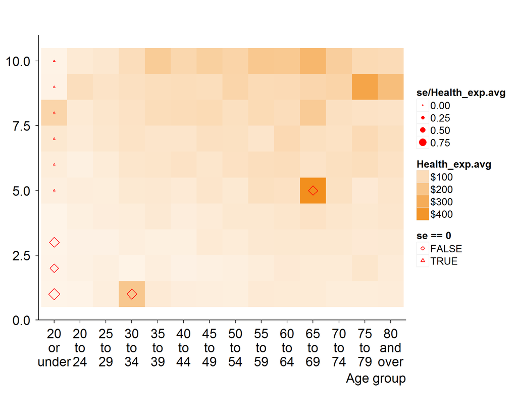

```r
health_by_age_income <-
  hes10hh %>%
  mutate(
    age_group = as.character(Age_of_HH_reference_person),
    age_group = ifelse(grepl("^[0-9]+$", age_group),
                       ifelse(as.numeric(age_group) < 20,
                              "20 or under",
                              paste((as.numeric(age_group) %/% 5) * 5,
                                    "to",
                                    (as.numeric(age_group) %/% 5) * 5 + 4)),
                       age_group
    )
  ) %>%
  mutate(Total_income_decile = factor(as.numeric(cut(Current_weekly_HH_disposable_income,
                                                   breaks = total.inc.deciles,
                                                   include.lowest = TRUE)))) %>%
  merge(chessboard, by = c("age_group", "Total_income_decile"), all.y = TRUE) %>%
  ## HOT DECK
  VIM::hotdeck(., variable = "Household_weekly_expenditure_on_medical_care_and_health_expenses_HES_only") %>%
  mutate(Unique_household_number = ifelse(is.na(Unique_household_number),
                                          paste0(lag(Unique_household_number), "x"),
                                          Unique_household_number),
         Weight_HH_HES = ifelse(is.na(Weight_HH_HES),
                                max(Weight_HH_HES, na.rm = TRUE),
                                Weight_HH_HES)) %>%
  svydesign(~Unique_household_number, data = ., weights = ~Weight_HH_HES) %>%
  svyby(~Household_weekly_expenditure_on_medical_care_and_health_expenses_HES_only, ~Total_income_decile + age_group, ., svymean) %>%
  setnames(c("Total_income_decile",
             "age_group",
             "Health_exp.avg",
             "se")) %>%
  setattr(c("call", "svyby"), c(NULL, NULL)) %>%
  mutate(Total_income_decile = as.integer(as.character(Total_income_decile))) %>%
  mutate(age_group_text = gsub("\\s+", "\n", age_group))

grplot(data = health_by_age_income,
       aes(x = age_group_text,
           y = Total_income_decile,
           alpha = Health_exp.avg)) +
  geom_tile(fill = Orange) +
  # se == 0 is also suspicious: it suggests there was only one observation in that group.
  geom_point(data = filter(health_by_age_income, 1.96 * se > Health_exp.avg | se == 0),
             aes(size = se/Health_exp.avg,
                 shape = se == 0),
             color = "red", alpha= 1) +
  xlab("Age group") +
  scale_shape_manual(values = c(23, 24)) +
  scale_alpha_continuous(label=grattan_dollar) +
  coord_equal() +
  theme_grattan(base_size = 18) +
  theme(panel.grid.major.y = element_blank(),
        legend.position = "right")
```

# Expand quintiles to deciles

## Split the difference

## Education

```r
education_by_incomeQ <-
  read_excel("Education_HES10_detailed.xlsx", sheet = "Education_by_income") %>%
  filter(as.logical(Total)) %>% select(-Total, -Subgroup) %>%
  gather(Quintile, amount, Q1:Q5) %>%
  mutate(amount = as.numeric(gsub("*", "", amount, fixed = TRUE))) %>%
  mutate(Quintile = as.integer(gsub("Q", "", Quintile))) %>%
  group_by(Quintile) %>%
  summarise(education.exp.Q = sum(amount)) %>%
  ungroup %>%
  mutate(education.exp.prop.Q = education.exp.Q / sum(education.exp.Q)) %>%
  data.table %>%
  setkey(Quintile)

education_by_age.names <-
  read_excel("Education_HES10_detailed.xlsx", sheet = "Education_by_age") %>%
  names

education_by_age <-
  read_excel("Education_HES10_detailed.xlsx", sheet = "Education_by_age") %>%
  gather_("age_group", "amount", grep("^[1-9]", education_by_age.names, value = TRUE)) %>%
  filter(as.logical(Total)) %>% select(-Total, -Subgroup) %>%
  mutate(amount = as.numeric(gsub("*", "", amount, fixed = TRUE))) %>%
  group_by(age_group) %>%
  summarise(education.exp.age = sum(amount)) %>%
  ungroup %>%
  mutate(education.exp.prop.age = education.exp.age / sum(education.exp.age)) %>%
  data.table %>%
  setkey(age_group)

# Assume that every age has the same distribution of education expenses by income
education_by_age_income <-
data.table::CJ(
  Quintile = c(1:5, (1:5-0.5)),
  age_group = education_by_age$age_group
) %>%
  merge(., education_by_age, by = "age_group") %>%
  setkey(Quintile) %>%
  merge(., education_by_incomeQ) %>%
  mutate(est.education.spend = education.exp.age * education.exp.prop.Q) %>%
  right_join(.,
    data.table(Quintile = rep(1:5, each = 2),
               Decile = 1:10)
  ) %>%
  mutate(
    education.exp.est_decile = est.education.spend / 2
  )
```

# Childcare

```r
childcare_by_age <-
  read_excel("EducationChildcare_HES10_detailed.xlsx", sheet = "Childcare_by_age") %>%
  gather(age_group, child_care.expAge, -Group) %>%
  data.table

childcare_by_income <-
  read_excel("EducationChildcare_HES10_detailed.xlsx", sheet = "Childcare_by_income") %>%
  gather(Quintile, child_care.expQ, -Group) %>%
  mutate(Quintile = as.integer(factor(Quintile))) %>%
  filter(complete.cases(.)) %>%
  mutate(child_care.expQ.prop = child_care.expQ/sum(child_care.expQ)) %>%
  data.table

childcare_by_age_income <-
  data.table::CJ(
    Quintile = 1:5,
    age_group = childcare_by_age$age_group
  ) %>%
  setkey(Quintile) %>%
  merge(., childcare_by_income) %>%
  setkey(age_group) %>%
  merge(., childcare_by_age) %>%
  mutate(child_care.exp.est = child_care.expAge * child_care.expQ.prop) %>%
  select(age_group, Quintile, child_care.exp.est) %>%
  right_join(.,
    data.table(Quintile = rep(1:5, each = 2),
               Decile = 1:10)
  ) %>%
  mutate(
    child_care.exp.est_decile = child_care.exp.est / 2
  )
```

# All together now

```r
age_group_tbl <-
  fread("age_table.csv")

food_by_age_income %<>%
  select(Total_income_decile, age_group, Food_GST) %>%
  # Check that this is indeed the right variable
  setnames("Food_GST", "est.expenditure") %>%
  mutate(Group = "Food")

health_by_age_income %<>%
  select(Total_income_decile, age_group, Health_exp.avg) %>%
  setnames("Health_exp.avg", "est.expenditure") %>%
  mutate(Group = "Health")

education_by_age_income %<>%
  select(Decile, age_group, est.education.spend) %>%
  # Note that this is not strictly true: it's household income.
  setnames(c("Decile", "est.education.spend"),
           c("Total_income_decile", "est.expenditure")) %>%
  merge(., age_group_tbl, by.x = "age_group", by.y = "big_age") %>%
  group_by(Total_income_decile, little_age) %>%
  # assign equally among each subage
  mutate(n = n()) %>%
  mutate(est.expenditure = est.expenditure / n) %>%
  mutate(Group = "Education")  %>%
  setnames("little_age", "age_group")

childcare_by_age_income %<>%
  select(Decile, age_group, child_care.exp.est_decile) %>%
  setnames(c("Decile", "child_care.exp.est_decile"),
           c("Total_income_decile", "est.expenditure")) %>%
  merge(., age_group_tbl, by.x = "age_group", by.y = "big_age") %>%
  group_by(Total_income_decile, little_age) %>%
  # assign equally among each subage
  mutate(n = n()) %>%
  mutate(est.expenditure = est.expenditure / n) %>%
  mutate(Group = "Childcare") %>%
  setnames("little_age", "age_group")

GST_by_age_and_income <-
bind_rows(food_by_age_income,
          health_by_age_income,
          education_by_age_income,
          childcare_by_age_income) %>%
  group_by(Total_income_decile, age_group) %>%
  summarise(total.expenditure = sum(est.expenditure) * GST_inflator_from0910_to1314) %>%
  mutate(age_group_text = gsub("\\s+", "\n", age_group)) %>%
  ungroup %>%
  mutate(extra_gst = 0.1 * total.expenditure)
```

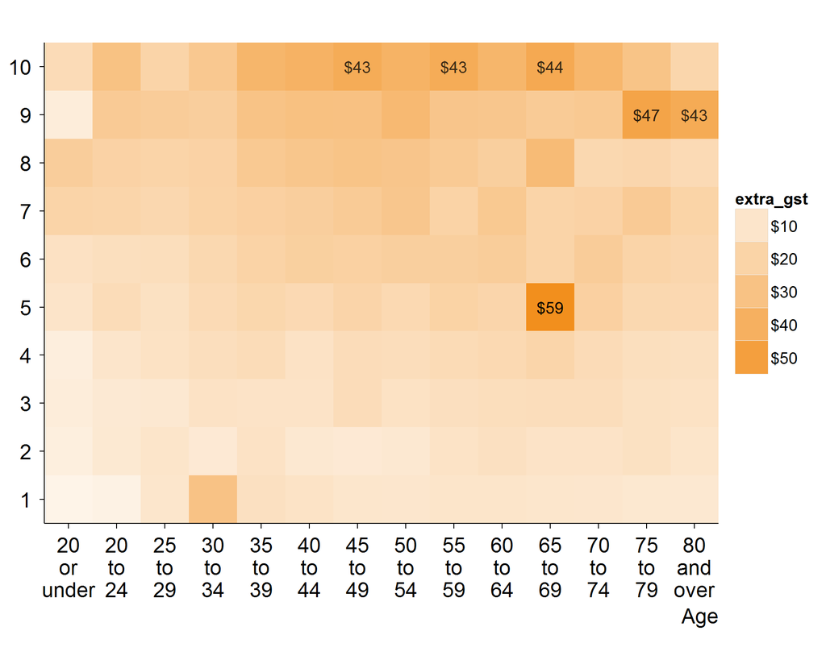

```r
GST_by_age_and_income  %>%
  grplot(aes(x = factor(age_group_text),
             y = factor(Total_income_decile),
             alpha = extra_gst)) +
  geom_tile(fill = Orange) +
  geom_text(data = tail(arrange(GST_by_age_and_income, extra_gst)),
            aes(label = grattan_dollar(extra_gst)),
            show_guide = FALSE) +
  scale_alpha_continuous(label=grattan_dollar) +
  scale_x_discrete(expand = c(0,0)) +
  scale_y_discrete(expand = c(0,0)) +
  xlab("Age") +
  coord_equal() +
  theme_grattan(base_size = 18) +
  theme(panel.grid.major.y = element_blank(),
        legend.position = "right",
        legend.key.size = unit(2, "lines"))
```

# Comparison to household numbers

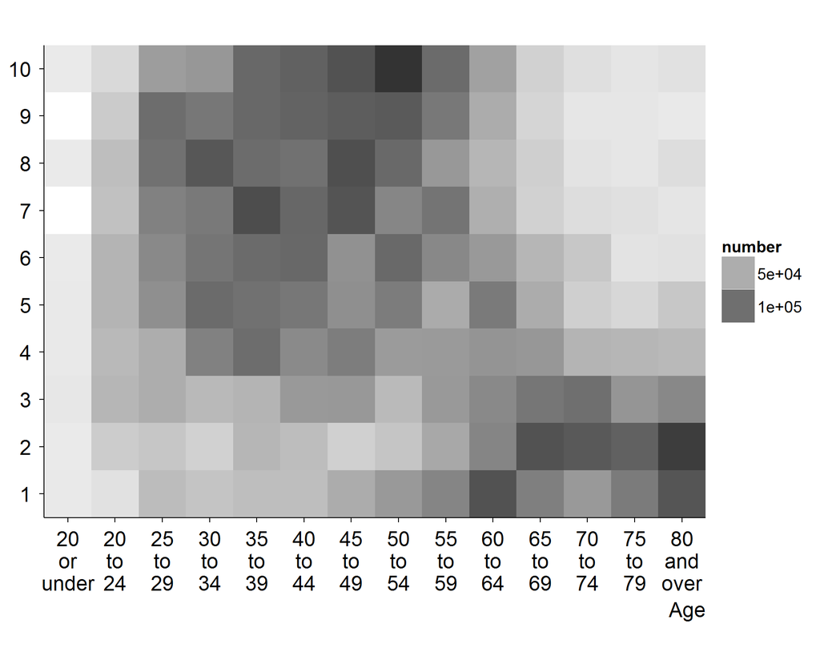

```r
number_households_by_age_income <-
  hes10hh %>%
  mutate(
    age_group = as.character(Age_of_HH_reference_person),
    age_group = ifelse(grepl("^[0-9]+$", age_group),
                       ifelse(as.numeric(age_group) < 20,
                              "20 or under",
                              paste((as.numeric(age_group) %/% 5) * 5,
                                    "to",
                                    (as.numeric(age_group) %/% 5) * 5 + 4)),
                       age_group
    )
  ) %>%
  mutate(total.inc.deciles = factor(as.numeric(cut(Total_current_weekly_HH_income_from_all_sources,
                                                   breaks = total.inc.deciles,
                                                   include.lowest = TRUE)))) %>%
  group_by(age_group, total.inc.deciles) %>%
  summarise(number = sum(Weight_HH_HES)) %>%
  mutate(age_group_text = gsub("\\s+", "\n", age_group)) %>%
  ungroup

number_households_by_age_income %>%
  grplot(aes(x = age_group_text,
             y = factor(total.inc.deciles),
             alpha = number)) +
  geom_tile() +
  scale_x_discrete(expand = c(0,0)) +
  scale_y_discrete(expand = c(0,0)) +
  xlab("Age") +
  coord_equal() +
  theme_grattan(base_size = 18) +
  theme(panel.grid.major.y = element_blank(),
        legend.position = "right",
        legend.key.size = unit(2, "lines"))
```

# GST for deciles relative to welfare

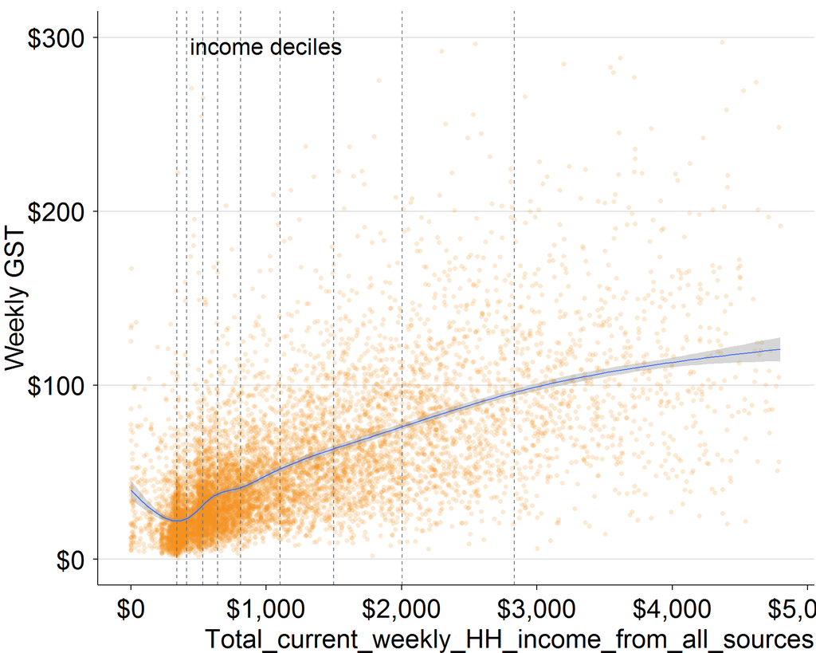

```r
hes10hh %>%
  select(Weekly_household_GST_on_all_goods_and_services_FIS
         , Current_weekly_HH_income_from_government_pensions_and_allowances
         , Age_of_HH_reference_person
         , Total_current_weekly_HH_income_from_all_sources) %>%
  group_by(
    Income_decile = ntile(Total_current_weekly_HH_income_from_all_sources, 10)
  ) %>%
  mutate(
    decile_cuts = min(Total_current_weekly_HH_income_from_all_sources)
  ) %>%
  grplot(aes(x = Total_current_weekly_HH_income_from_all_sources,
             y = Weekly_household_GST_on_all_goods_and_services_FIS)) +
  geom_point(alpha = 0.2) +
  geom_vline(aes(xintercept = decile_cuts), colour = theGrey, linetype = 2) +
  stat_smooth()  +
  scale_y_continuous("Weekly GST",
                     limits = c(0,300),
                     label = grattan_dollar) +
  scale_x_continuous(label = grattan_dollar,
                     limits = c(-2, 250e3/52)) +
  theme(axis.title.y = element_text(angle = 90)) +
  annotate("text",
           x = 1000,
           y = 300,
           vjust = 1,
           size = 7.14,
           label = "income deciles")
```

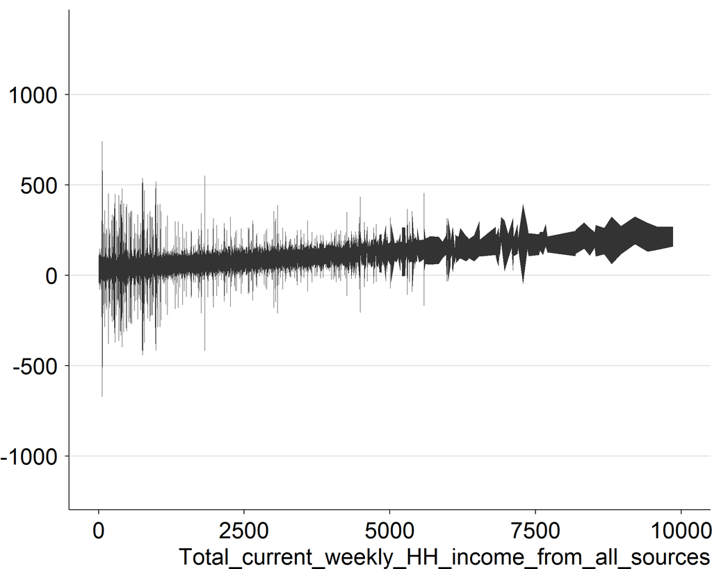

```r
lm.income.gst <- lm(Weekly_household_GST_on_all_goods_and_services_FIS ~ Total_current_weekly_HH_income_from_all_sources,
                    data = hes10hh, weights = Weight_HH_HES)

hes10hh.pred <-
  predict(lm.income.gst, interval = "prediction") %>%
  cbind(Total_current_weekly_HH_income_from_all_sources = hes10hh$Total_current_weekly_HH_income_from_all_sources_basis) %>%
  as.data.frame %>%
  tbl_df

hes10hh %>%
  #group_by.income_quintile %>%
  grplot(aes(x = Total_current_weekly_HH_income_from_all_sources
             #,y = Weekly_household_GST_on_all_goods_and_services_FIS)
             )) +
  #geom_point(aes(alpha = Weight_HH_HES/max(Weight_HH_HES))) +
  geom_ribbon(data = hes10hh.pred,
              mapping = aes(ymax = upr, ymin = lwr)) +
  scale_alpha_identity() +
  xlim(-5, 10e3)
```

## Perfect GST substitution

### Broadening the base

```r
HH_GST_expenditure_by_quintile <-
  read_excel("HH_GST_expenditure_by_quintile.xlsx", sheet = "GST_by_quintile") %>%
  gather(Quintile, weekly_expenditure, Q1:Q5) %>%
  filter(!grepl("[12]$", Category)) %>% #Education_1/2 are subcategories, may be ignored.
  group_by(total.inc.quintiles = as.integer(factor(Quintile))) %>%
  summarise(GST_expenditure = sum(weekly_expenditure)/10) %>%
  data.table %>%
  setkey(total.inc.quintiles)

hes10hh %>%
  # get the quintiles:
  mutate(total.inc.quintiles = factor(as.numeric(cut(Total_current_weekly_HH_income_from_all_sources,
                                                     breaks = total.inc.quintiles,
                                                     include.lowest = TRUE))))   %>%
  inner_join(HH_GST_expenditure_by_quintile) %>%
  data.table %>%
  mutate(share_of_spending = GST_expenditure * Weight_HH_HES * 52.5 ) %>%
  group_by(total.inc.quintiles) %>%
  summarise(avg.pension = weighted.mean(Current_weekly_HH_income_from_government_pensions_and_allowances > 0, Weight_HH_HES))
```

```
## Source: local data table [5 x 2]
##
##   total.inc.quintiles avg.pension
##                (fctr)       (dbl)
## 1                   1   0.8432522
## 2                   2   0.7209734
## 3                   3   0.5298150
## 4                   4   0.4164230
## 5                   5   0.1971715
```

### 15 per cent

```r
hes10hh %>%
  select(Weekly_household_GST_on_all_goods_and_services_FIS
         , Current_weekly_HH_income_from_government_pensions_and_allowances
         , Age_of_HH_reference_person
         , Total_current_weekly_HH_income_from_all_sources) %>%
  group_by(
    Income_decile = ntile(Total_current_weekly_HH_income_from_all_sources, 10)
  ) %>%
  mutate(
    GST_extra = Weekly_household_GST_on_all_goods_and_services_FIS / 3,
    new_income_required = Current_weekly_HH_income_from_government_pensions_and_allowances + ifelse(Income_decile < 2,
                                                                                                    GST_extra,
                                                                                                    0)
  ) %>%
  grplot(aes(x = Total_current_weekly_HH_income_from_all_sources,
             y = Weekly_household_GST_on_all_goods_and_services_FIS)) +
  geom_point() +
  ylab("Weekly GST")
```

# GST for bottom 3 quintiles

# Household ratios of income

```r
hes10hh %>%
  select(Weekly_household_GST_on_all_goods_and_services_FIS
         , Weekly_household_final_income_FIS
         , Weight_HH_HES
         , Household_weekly_expenditure_on_income_tax_HES_only) %>%
  mutate(ratio_GST = Weekly_household_GST_on_all_goods_and_services_FIS / Weekly_household_final_income_FIS) %>%
  group_by(Income_quintile = ntile(Weekly_household_final_income_FIS, 5)) %>%
  summarise(mean_ratio = weighted.mean(ratio_GST, w = Weight_HH_HES),
            #se_ratio = weighted.var.se(ratio_GST, w = Weight_HH_HES),
            max_income = max(Weekly_household_final_income_FIS * 52.5),
            mean_income_tax = weighted.mean(Household_weekly_expenditure_on_income_tax_HES_only, w = Weight_HH_HES),
            max_income_tax = max(Household_weekly_expenditure_on_income_tax_HES_only),
            prop_zero_income_tax = mean(Household_weekly_expenditure_on_income_tax_HES_only < 1)
            ) %>%
  arrange(Income_quintile)
```

```
## Source: local data table [5 x 6]
##
##   Income_quintile mean_ratio max_income mean_income_tax max_income_tax
##             (dbl)      (dbl)      (dbl)           (dbl)          (dbl)
## 1               1 0.06906682   41902.35        22.09492         451.89
## 2               2 0.04119508   57401.92        61.48798         636.29
## 3               3 0.04283945   74781.00       111.54318         714.77
## 4               4 0.03814142  105323.93       210.03037        1076.82
## 5               5 0.03513930 3145889.82       619.80885        9491.89
## Variables not shown: prop_zero_income_tax (dbl)
```

# Current base

## Current GST per household

```r
hes10hh %>%
  select(Weekly_household_GST_on_all_goods_and_services_FIS
         , Total_current_weekly_HH_income_from_all_sources
         , Weekly_household_final_income_FIS
         , Weight_HH_HES
         , Household_weekly_expenditure_on_income_tax_HES_only) %>%
  group_by(Gross_income_quintile = factor(as.numeric(cut(Total_current_weekly_HH_income_from_all_sources,
                                                     breaks = total.inc.quintiles,
                                                     include.lowest = TRUE)))) %>%
  summarise(avg.GST = weighted.mean(Weekly_household_GST_on_all_goods_and_services_FIS,
                                    Weight_HH_HES)) %>%
  ungroup %>%
  mutate(prop.GST = avg.GST/sum(avg.GST)) %>%
  arrange(Gross_income_quintile)
```

```
## Source: local data table [5 x 3]
##
##   Gross_income_quintile   avg.GST   prop.GST
##                  (fctr)     (dbl)      (dbl)
## 1                     1  28.62323 0.08848356
## 2                     2  43.06993 0.13314294
## 3                     3  59.95405 0.18533713
## 4                     4  76.67331 0.23702170
## 5                     5 115.16592 0.35601468
```

```r
# GST_15_by_age_income <-
#   hes10hh %>%
#   age_mutate %>%
#   group_by(# needs to be weighted Income_decile = ntile(Weekly_household_final_income_FIS, 10), age_group) %>%
#   summarise(avg.GST.15 = 1.5 * weighted.mean(Weekly_household_GST_on_all_goods_and_services_FIS,
#                                              Weight_HH_HES)) %>%
#   ungroup %>%
#   mutate(avg.GST.15 = avg.GST.15 * GST_inflator_from0910_to1314) %>%
#   mutate(extra_gst = avg.GST.15 / 3)  # 5 percentage points = 15 / 3
```

```r
# GST_15_by_age_income  %>%
#   grplot(aes(x = age_group, y = Income_decile, alpha = extra_gst)) +
#   geom_tile(fill = Orange) +
#   geom_text(data = tail(arrange(GST_15_by_age_income, extra_gst)),
#             aes(label = grattan_dollar(extra_gst)),
#             show_guide = FALSE) +
#   scale_alpha_continuous(label=grattan_dollar) +
#   scale_x_discrete(expand = c(0,0)) +
#   scale_y_discrete(expand = c(0,0)) +
#   xlab("Age") +
#   coord_equal() +
#   theme_grattan(base_size = 18) +
#   theme(panel.grid.major.y = element_blank(),
#         legend.position = "right",
#         legend.key.size = unit(2, "lines"))
```

# Deloitte study

I use the 2009-10 HES/FIS to estimate the effect of a 5 percentage point raise in a 10% GST. I then hardcoded the numbers from the Deloitte report to determine the size of their proposed compensatory transfers as a function of the extra GST raised.

```r
# 15 pc.
extra_gst_raised <-
  hes10hh %$%
  # Divide by 2 because 10/2 = 5, a 5 percentage point increase in GST.
  sum(Weekly_household_GST_on_all_goods_and_services_FIS * Weight_HH_HES) * 52.5 / 2

welfare.from.hes <-
  hes10hh %$%
  sum(Current_weekly_HH_income_from_government_pensions_and_allowances * Weight_HH_HES) * 52.5

gst.raised.in.200910 <- 46553 * 10^6
# gst.raised.in.200910 / (2*extra_gst_raised)
## [1] 1.631501

welfare.in.200910 <- (110994 - 3831) * 10^6  # total social security + welfare minus admin.
# welfare.in.200910 / welfare.from.hes
## [1] 1.357734

compensatory.transfers <-
  # A quarter of money raised goes to tax cuts and transfers.
  # Transfers = 16 bn, tax cuts = 21 bn (which is over four years
  # but that is relevant here).
  (1/4)*((16/(16+21))) * extra_gst_raised

proportion_of_welfare_by_quintile <-
  hes10hh %>%
  group_by(Gross_income_quintile = factor(as.numeric(cut(Total_current_weekly_HH_income_from_all_sources,
                                                         breaks = total.inc.quintiles,
                                                         include.lowest = TRUE)))) %>%
  summarise(total_welfare = sum(Current_weekly_HH_income_from_government_pensions_and_allowances * Weight_HH_HES),
            extra_gst = sum(Weekly_household_GST_on_all_goods_and_services_FIS * Weight_HH_HES) / 2) %>%
  ungroup %>%
  mutate(extra_gst.prop = extra_gst / sum(extra_gst),
         prop_welfare = total_welfare/sum(total_welfare),
         implied_transfr = prop_welfare * compensatory.transfers / 52.5,
         comp_adequacy = implied_transfr/extra_gst)
```

## Deloitte double donut

Assuming perfect precision in welfare means testing (‘well-targeted payments’),

```r
data.frame(expense = c("Net revenue gain", "Personal tax cuts", "Transfer payments"),
                    number = c(115,21,16)) %>%
  mutate(fraction = number/sum(number)) %>%
  arrange(fraction) %>%
  mutate(ymax = cumsum(fraction),
         ymin = c(0, lag(ymax)[-1])) %>%
  grplot(aes(fill = expense, ymax = ymax, ymin = ymin, xmax = 4, xmin = 3)) +
  geom_rect(colour = theGrey) +
  geom_text(aes(x = 4.5, y = 0.5 * (ymin + ymax), label = expense)) +
  coord_polar(theta = "y") +
  xlim(0,4.6) +
  theme(panel.grid = element_blank(),
        axis.text = element_blank(),
        axis.ticks = element_blank(),
        axis.title = element_blank(),
        axis.line = element_blank())
```

```r
proportion_of_welfare_by_quintile %>%
  mutate(fraction = extra_gst.prop) %>%
  arrange(fraction) %>%
  mutate(ymax = cumsum(fraction),
         ymin = c(0, lag(ymax)[-1])) %>%
  grplot(aes(fill = Gross_income_quintile, ymax = ymax, ymin = ymin, xmax = 4, xmin = 3)) +
  geom_rect(colour = theGrey) +
  geom_text(aes(x = 4.5, y = 0.5 * (ymin + ymax), label = Gross_income_quintile)) +
  coord_polar(theta = "y")+
  xlim(0,4.6) +
  theme(panel.grid = element_blank(),
        axis.text = element_blank(),
        axis.ticks = element_blank(),
        axis.title = element_blank(),
        axis.line  = element_blank())
```

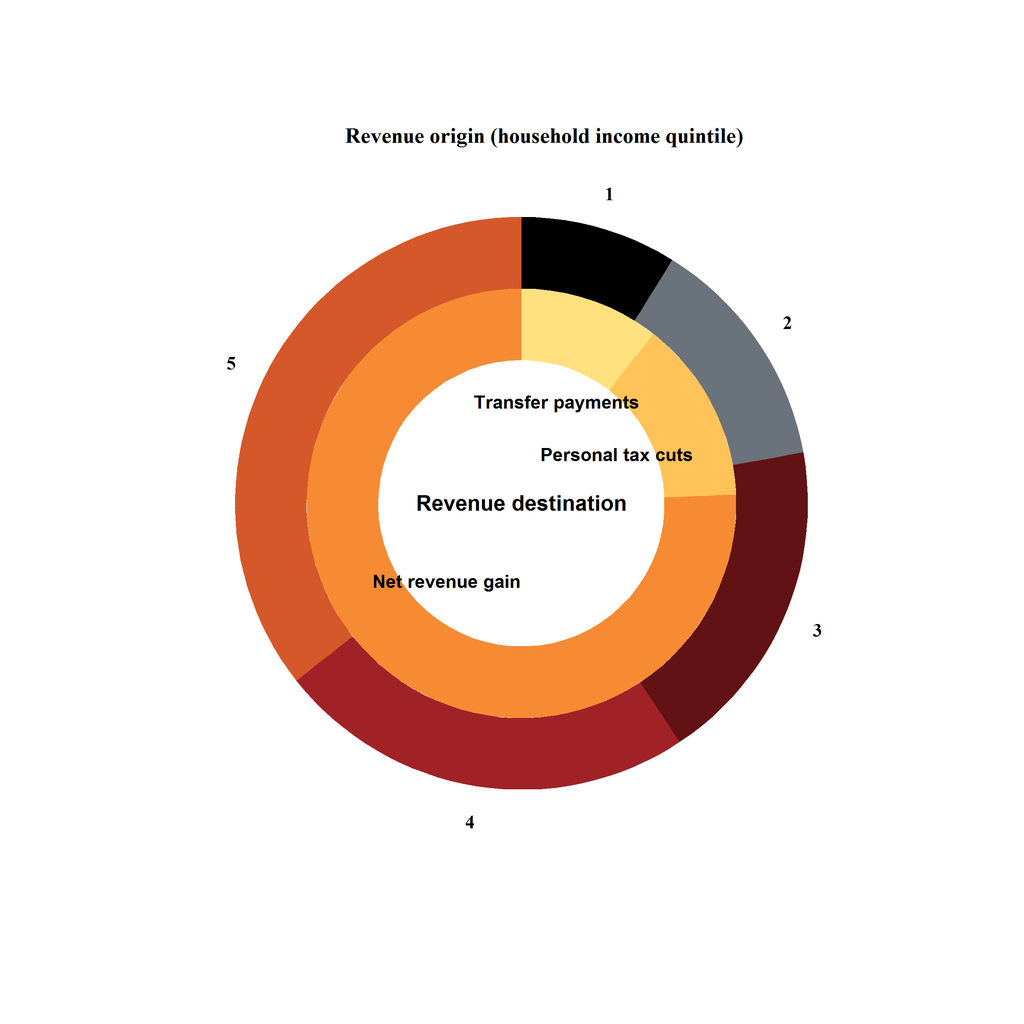

```r
outside <-
  proportion_of_welfare_by_quintile %>%
  mutate(fraction = extra_gst.prop) %>%
  arrange(fraction) %>%
  mutate(ymax = cumsum(fraction),
         ymin = c(0, lag(ymax)[-1]))

inside <-
  data.frame(expense = c("Net revenue gain", "Personal tax cuts", "Transfer payments"),
                    number = c(115,21,16)) %>%
  mutate(fraction = number/sum(number)) %>%
  arrange(fraction) %>%
  mutate(ymax = cumsum(fraction),
         ymin = c(0, lag(ymax)[-1]))

grplot(NULL) +
  geom_rect(data = inside, aes(fill = expense, ymax = ymax, ymin = ymin, xmax = 3, xmin = 2)) +
  geom_rect(data = outside, aes(fill = Gross_income_quintile, ymax = ymax, ymin = ymin, xmax = 4, xmin = 3)) +
  coord_polar(theta = "y") +
  xlim(0, 5.5) +
  geom_text(data = outside, aes(x = 4.5, y = 0.5 * (ymin + ymax), label = Gross_income_quintile),
            fontface = "bold", size = 6, family = "serif")  +
  geom_text(data = inside, aes(x = 1.5, y = 0.5 * (ymin + ymax), label = expense),
            fontface = "bold", size = 6) +
  theme(panel.grid = element_blank(),
        axis.text = element_blank(),
        axis.ticks = element_blank(),
        axis.title = element_blank(),
        axis.line = element_blank()) +
  annotate("text",
           x = 0.01,
           y = 0.01,
           fontface = "bold",
           size = 7,
           label = "Revenue destination") +
  annotate("text",
           x = 5.15,
           y = 0.01,
           hjust = 0.5,
           fontface = "bold",
           size = 7,
           family = "serif",
           label = "Revenue origin (household income quintile)")
```

## But this does not paint the full picture

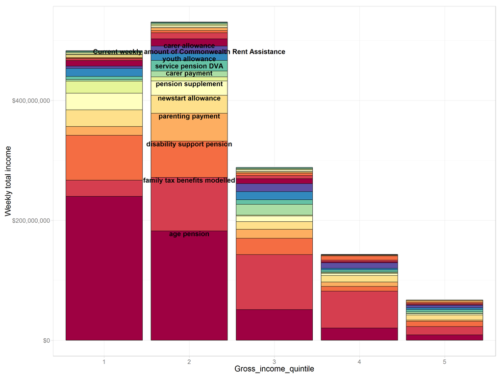

```r
welfare.by.income.quintile <-
  hes10_indiv %>%
  merge(hes10hh, by = "Unique_household_number", suffixes = c("indiv", "hh")) %>%
  mutate(Gross_income_quintile = factor(as.numeric(cut(Total_current_weekly_HH_income_from_all_sources,
                                                       breaks = total.inc.quintiles,
                                                       include.lowest = TRUE)))) %>%
  select(Unique_household_number, Gross_income_quintile,
         Weight_Person_HES,
         Current_weekly_amount_of_Commonwealth_Rent_Assistance, Current_weekly_income_from_age_pension, Current_weekly_income_from_wife_pension, Current_weekly_income_from_carer_payment,
         Current_weekly_income_from_carer_allowance, Current_weekly_income_from_special_benefit, Current_weekly_income_from_widow_allowance, Current_weekly_income_from_youth_allowance, Current_weekly_income_from_Austudy_Abstudy, Current_weekly_income_from_parenting_payment, Current_weekly_income_from_Baby_Bonus_payment, Current_weekly_income_from_partner_allowance, Current_weekly_income_from_senior_supplement, Current_weekly_income_from_newstart_allowance, Current_weekly_income_from_pension_supplement, Current_weekly_income_from_sickness_allowance, Current_weekly_income_from_service_pension_DVA, Current_weekly_income_from_utilities_allowance, Current_weekly_income_from_disability_pension_DVA, Current_weekly_income_from_war_widows_pension_DVA, Current_weekly_income_from_disability_support_pension, Current_weekly_income_from_family_tax_benefits_modelled, Current_weekly_income_from_other_government_pensions_and_allowances) %>%
  gather(Allowance, income, -Unique_household_number, -Gross_income_quintile, -Weight_Person_HES) %>%
  data.table %>%
  mutate(Allowance = gsub("Current_weekly_income_from_", "", Allowance, fixed = TRUE)) %>%
  group_by(Gross_income_quintile, Allowance) %>%
  summarise(total = sum(income * Weight_Person_HES)) %>%
  ungroup %>%
  arrange(desc(total))


welfare.by.income.quintile %>%
  mutate(Allowance = factor(Allowance, levels = (welfare.by.income.quintile$Allowance), ordered = TRUE)) %>%
  mutate(text = ifelse(Gross_income_quintile == 2 & total > 1e7, gsub("_", " ", Allowance, fixed = TRUE), NA_character_)) %>%
  group_by(Gross_income_quintile) %>%
  arrange(desc(total)) %>%
  mutate(text.y = cumsum(total)) %>%
  ggplot(aes(x = Gross_income_quintile, fill = Allowance, order = Allowance)) +
  geom_bar(aes(y = total), stat = "identity", position = "stack") +
  geom_text(aes(label = text, y = text.y), vjust = 1, fontface = "bold", size = 5.5) +
  scale_fill_manual(values = c(rep(RColorBrewer::brewer.pal(11, name="Spectral"), 2), "black")) +
  scale_y_continuous("Weekly total income", label = grattan_dollar) +
  theme_light(base_size = 18) +
  theme(legend.position = "none")
```

```r
proportion_of_welfare_by_quintile.tots <-
  proportion_of_welfare_by_quintile %>%
  ungroup %>%
  summarise(Total = sum)

proportion_of_welfare_by_quintile_pretty <-
  proportion_of_welfare_by_quintile %>%
  arrange(Gross_income_quintile) %>%
  mutate(`Q` = Gross_income_quintile,
         `Total welfare` = grattan_dollar(total_welfare * 52.5),
         `Increased GST burden` = grattan_dollar(extra_gst * 52.5),
         `(%)` = scales::percent(extra_gst.prop),
         `% of total welfare` = scales::percent(prop_welfare),
         `Implied compo` = grattan_dollar(implied_transfr * 52.5),
         `Compo adeq.` = scales::percent(comp_adequacy)) %>%
  select(-contains("_"))

kable(proportion_of_welfare_by_quintile_pretty,
      align = rep("r", ncol(proportion_of_welfare_by_quintile_pretty)))
```

| Q | Total welfare | Increased GST burden | (%) | % of total welfare | Implied compo | Compo adeq. |
| --- | --- | --- | --- | --- | --- | --- |
| 1 | $25,116,441,300 | $1,260,141,280 | 8.8% | 31.8% | $490,813,672 | 38.9% |
| 2 | $27,661,542,827 | $1,900,840,199 | 13.3% | 35.0% | $540,548,847 | 28.4% |
| 3 | $14,965,846,879 | $2,642,942,568 | 18.5% | 19.0% | $292,455,534 | 11.1% |
| 4 | $7,582,227,737 | $3,379,991,171 | 23.7% | 9.6% | $148,168,325 | 4.4% |
| 5 | $3,601,758,109 | $5,083,009,495 | 35.6% | 4.6% | $70,383,861 | 1.4% |

## Household expenditure per week by gross income

```r
final.income.quintiles <-
  hes10hh %>%
  svydesign(~Unique_household_number, data = ., weights = ~Weight_HH_HES) %>%
  svyquantile(~Weekly_household_final_income_FIS
              ,.
              #, quantiles = c(0:5)/5)
              ,quantiles = c(0:5)/5
              )

hes10hh %>%
  group_by(
    Gross_income_quintile = factor(as.numeric(cut(Weekly_household_final_income_FIS,
                                                     breaks = final.income.quintiles,
                                                     include.lowest = TRUE)))
  ) %>%
  summarise(
    average_total_spending = weighted.mean(Total_household_expenditure_including_selected_other_payments_HES_only, Weight_HH_HES),
    average_extra_gst = weighted.mean(Weekly_household_GST_on_all_goods_and_services_FIS, Weight_HH_HES) / 2,
    average_welfare_payments = weighted.mean(Current_weekly_HH_income_from_government_pensions_and_allowances, Weight_HH_HES),
    average_income = weighted.mean(Weekly_household_final_income_FIS, Weight_HH_HES)
  ) %>%
  arrange(Gross_income_quintile) %>%
  ungroup %>%
  mutate(prop_income_on_extra_gst = average_extra_gst / average_income,
         prop_income_spending = average_total_spending / average_income
         )
```

```
## Source: local data table [5 x 7]
##
##   Gross_income_quintile average_total_spending average_extra_gst
##                  (fctr)                  (dbl)             (dbl)
## 1                     1               790.2768          17.08127
## 2                     2              1051.4623          22.64523
## 3                     3              1421.3637          29.82940
## 4                     4              1951.7805          36.73118
## 5                     5              3380.1208          55.49104
## Variables not shown: average_welfare_payments (dbl), average_income (dbl),
##   prop_income_on_extra_gst (dbl), prop_income_spending (dbl)
```

```r
hes10hh %>%
  group_by(
    Gross_income_quintile = factor(as.numeric(cut(Weekly_household_final_income_FIS,
                                                     breaks = final.income.quintiles,
                                                     include.lowest = TRUE)))
  ) %>%
  mutate(extra_gst = Weekly_household_GST_on_all_goods_and_services_FIS / 2) %$%
  sum(extra_gst * Weight_HH_HES) * 52.5 ->
  extra_gst_raised

compensatory.transfers <-
  ((16/(16+21))/4)*extra_gst_raised   # p. 15 of report

hes10hh %>%
  mutate(Gross_income_quintile = factor(as.numeric(cut(Weekly_household_final_income_FIS,
                                                     breaks = final.income.quintiles,
                                                     include.lowest = TRUE))),
         extra_gst = 52.5 * Weight_HH_HES * Weekly_household_GST_on_all_goods_and_services_FIS / 2,
         compensatory_transfer = ifelse(Gross_income_quintile == 1,
                                        compensatory.transfers / Weight_HH_HES,
                                        0),
         compensation_adequacy = compensatory_transfer / extra_gst) %>%
  group_by(Gross_income_quintile) %>%
  summarise(extra_gst_mean = weighted.mean(extra_gst, Weight_HH_HES),
            compensatory_transfer_mean = weighted.mean(compensatory_transfer, Weight_HH_HES)) %>%
  mutate(compensation_adequacy = compensatory_transfer_mean / extra_gst_mean)
```

```
## Source: local data table [5 x 4]
##
##   Gross_income_quintile extra_gst_mean compensatory_transfer_mean
##                  (fctr)          (dbl)                      (dbl)
## 1                     1        1433709                    2274580
## 2                     2        1863433                          0
## 3                     5        5359889                          0
## 4                     4        3430552                          0
## 5                     3        2589349                          0
## Variables not shown: compensation_adequacy (dbl)
```

```r
proportion_of_welfare_by_quintile <-
  hes10hh %>%
  group_by(Gross_income_quintile = factor(as.numeric(cut(Total_current_weekly_HH_income_from_all_sources,
                                                     breaks = total.inc.quintiles,
                                                     include.lowest = TRUE)))) %>%
  summarise(total_welfare = sum(Current_weekly_HH_income_from_government_pensions_and_allowances * Weight_HH_HES),
            extra_gst = sum(Weekly_household_GST_on_all_goods_and_services_FIS * Weight_HH_HES) / 2) %>%
  ungroup %>%
  mutate(prop_welfare = total_welfare/sum(total_welfare),
         implied_transfr = prop_welfare * compensatory.transfers / 52.5,
         comp_adequacy = implied_transfr/extra_gst)
```

## Tax cuts

By inspection of https://grattan.shinyapps.io/Forty_three_app/Forty_three_app.Rmd we see that a reduction in the bottom marginal tax rate from 19% to 15.5% results in a $5.6 billion decrease in revenue.

# Analysis of welfare

```r
sih11.raw <-
  read.dta("./SIH/sih11bp.dta") %>%
  data.table

sih11.names <-
  hes.sih.vars$SIH_basic_name[hes.sih.vars$SIH_basic_name %in% names(sih11.raw)]
sih11.newnames <-
  hes.sih.vars$Definition_new[hes.sih.vars$SIH_basic_name %in% names(sih11.raw)]

# SIHPSWT didn't come along for the ride
sih11.names <- c(sih11.names, "SIHPSWT")
sih11.newnames <- c(sih11.newnames, "Person_weight")

sih11 <-
  sih11.raw %>%
  select_(.dots = sih11.names) %>%
  setnames(old = sih11.names,
           new = sih11.newnames)
```

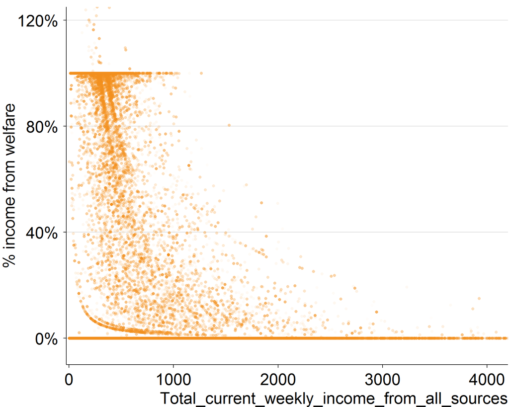

```r
sih11 %>%
  mutate(prop_welfare = Total_current_weekly_income_from_government_pensions_and_allowances / Total_current_weekly_income_from_all_sources) %>%
  filter(Total_current_weekly_income_from_all_sources >= 0) %>%
  grplot(aes(x = Total_current_weekly_income_from_all_sources, y = prop_welfare,
             alpha = Person_weight/max(Person_weight), weight = Person_weight)) +
  geom_point() +
  scale_alpha_identity() +
  scale_y_continuous("% income from welfare",
                     label = scales::percent) +
  coord_cartesian(xlim = c(-25,4.2e3),
                  ylim = c(-0.1,1.25)) +
  theme(axis.title.y = element_text(angle = 90))
```

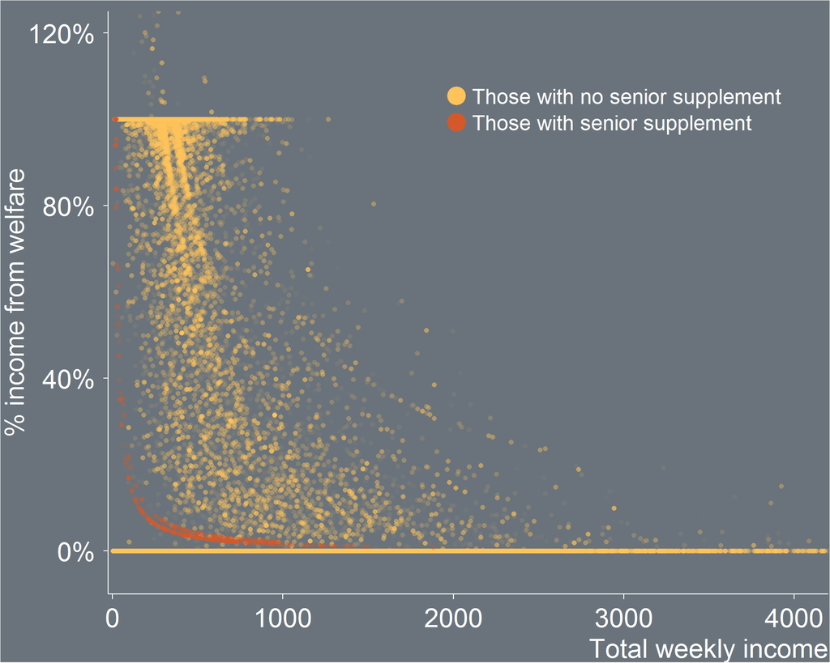

```r
sih11 %>%
  mutate(prop_welfare = Total_current_weekly_income_from_government_pensions_and_allowances / Total_current_weekly_income_from_all_sources) %>%
  mutate(has_age_pnsn = ifelse(Current_weekly_income_from_age_pension > 0,
                               "Age pension",
                               "No age pension"),
         has_fmly_bnft = Current_weekly_income_from_parenting_payment > 0,
         has_dsably = Current_weekly_income_from_disability_support_pension > 0,
         has_newstart = Current_weekly_income_from_newstart_allowance > 0,
         has_snrsupplment = ifelse(Current_weekly_income_from_senior_supplement > 0,
                                   "Those with senior supplement",
                                   "Those with no senior supplement")) %>%
  filter(Total_current_weekly_income_from_all_sources >= 0) %>%
  grplot(aes(x = Total_current_weekly_income_from_all_sources, y = prop_welfare,
             color = has_snrsupplment, order = has_snrsupplment,
             alpha = Person_weight/max(Person_weight), weight = Person_weight)) +
  geom_point() +
  scale_alpha_identity() +
  scale_color_manual(values = c("Those with senior supplement" = gpal(2)[1], "Those with no senior supplement" = gpal(2)[2])) +
  guides(color = guide_legend("", override.aes = list(size = 8))) +
  scale_y_continuous("% income from welfare",
                     label = scales::percent) +
  coord_cartesian(xlim = c(-25,4.2e3),
                  ylim = c(-0.1,1.25)) +
  xlab("Total weekly income") +
  theme(axis.title.y = element_text(angle = 90),
        legend.position = c(0.7,0.85),
        text = element_text(color = "white"),
        line = element_line(color = "white"),
        axis.line = element_line(color = "white"),
        panel.grid.major.y = element_blank(),
        axis.ticks = element_line(color = "white"),
        plot.background = element_rect(fill = theGrey),
        legend.key = element_rect(color = NA, fill=theGrey),
        legend.text = element_text(lineheight = 0.7))
```

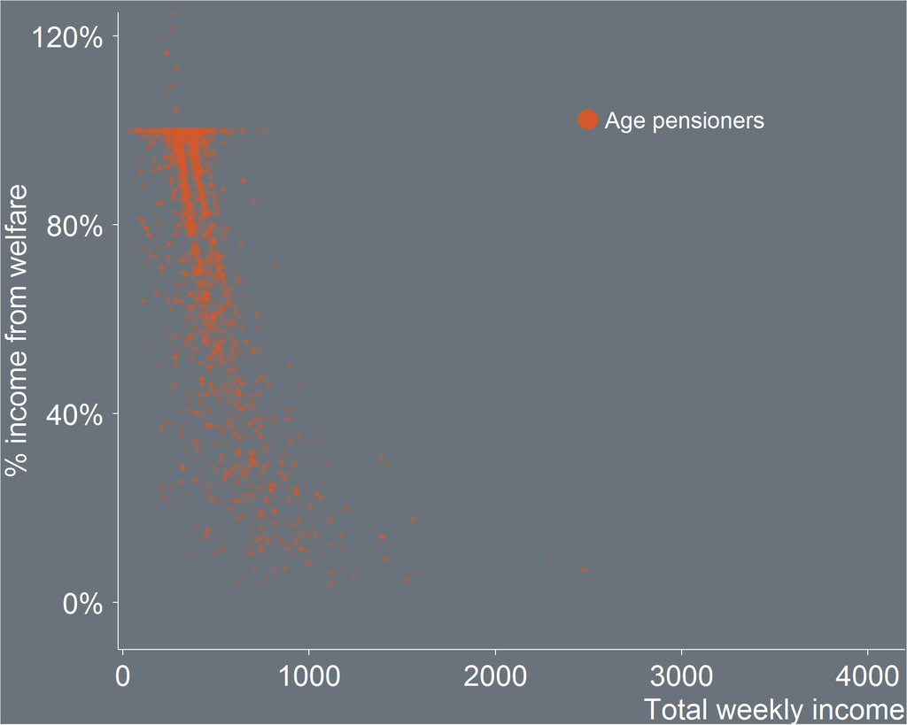

```r
sih11 %>%
  mutate(prop_welfare = Total_current_weekly_income_from_government_pensions_and_allowances / Total_current_weekly_income_from_all_sources) %>%
  mutate(has_age_pnsn = ifelse(Current_weekly_income_from_age_pension > 0,
                               "Age pensioners",
                               "No age pension"),
         has_fmly_bnft = Current_weekly_income_from_parenting_payment > 0,
         has_dsably = Current_weekly_income_from_disability_support_pension > 0,
         has_newstart = Current_weekly_income_from_newstart_allowance > 0,
         has_snrsupplment = ifelse(Current_weekly_income_from_senior_supplement > 0,
                                   "Senior supplement > 0",
                                   "No senior supplement")) %>%
  filter(Total_current_weekly_income_from_all_sources >= 0,
         Current_weekly_income_from_age_pension > 0) %>%
  grplot(aes(x = Total_current_weekly_income_from_all_sources, y = prop_welfare,
             color = has_age_pnsn, order = has_age_pnsn,
             alpha = Person_weight/max(Person_weight), weight = Person_weight)) +
  geom_point() +
  scale_alpha_identity() +
  scale_color_manual(values = c("Age pensioners" = gpal(2)[1], "No age pension" = gpal(2)[2])) +
  guides(color = guide_legend("", override.aes = list(size = 8))) +
  scale_y_continuous("% income from welfare",
                     label = scales::percent) +
  coord_cartesian(xlim = c(-25,4.2e3),
                  ylim = c(-0.1,1.25)) +
  xlab("Total weekly income") +
  theme(axis.title.y = element_text(angle = 90),
        legend.position = c(0.7,0.85),
        text = element_text(color = "white"),
        line = element_line(color = "white"),
        axis.line = element_line(color = "white"),
        panel.grid.major.y = element_blank(),
        axis.ticks = element_line(color = "white"),
        plot.background = element_rect(fill = theGrey),
        legend.key = element_rect(color = NA, fill=theGrey))
```

## What magnitude of compensation would be required in order for the lowest 20% disposable income would be compensated?

### 15% increase

```r
extra_gst.weekly <-
  hes10hh %$%
  sum(Weekly_household_GST_on_all_goods_and_services_FIS * Weight_HH_HES) / 2

temp.chessboard <-
  data.table::CJ(
    Unique_household_number = hes10hh$Unique_household_number,
    percentage_revenue = (0:100)/100,
    comp_adequacy = (1:7)/4
  )

temp.chessboard.2 <-
  data.table::CJ(
    Unique_household_number = hes10hh$Unique_household_number,
    percentage_revenue = (0:100)/100
  )

perfectly_targeted_efficacy.15pc <-
  hes10hh %>%
  select(Weekly_household_GST_on_all_goods_and_services_FIS,
         Total_current_weekly_HH_income_from_all_sources,
         Weight_HH_HES
         ,Unique_household_number
  ) %>%
  merge(., temp.chessboard.2, by = "Unique_household_number", all.y = TRUE) %>%
  group_by.income_quintile %>%
  ungroup %>%
  data.table %>%
  mutate(revenue_for_transfer = percentage_revenue * extra_gst.weekly) %>%
  group_by(percentage_revenue) %>%
  mutate(revenue_transfered = ifelse(income_quintile == 1,  # may be redundant but not sure
                                     # We multiply by 5 because all the money is transferred to the bottom
                                     # quintile.  I can't at this time convince myself why this
                                     # multiple is necessary -- except the numbers don't look right
                                     # without it.  In particular, even if all money is transferred to the
                                     # bottom quintile, a large minority of households are undercompensated.
                                     (five <- 5) * revenue_for_transfer/sum(Weight_HH_HES),
                                     0)) %>%
  data.table %>%
  filter(income_quintile == 1) %>%
  group_by(percentage_revenue) %>%
  summarise(
    percentage_compensated = weighted.mean(Weekly_household_GST_on_all_goods_and_services_FIS/2 < revenue_transfered,
                                           w = Weight_HH_HES))

perfectly_targeted_efficacy_comp_adequacy.15pc <-
  hes10hh %>%
  select(Weekly_household_GST_on_all_goods_and_services_FIS,
         Total_current_weekly_HH_income_from_all_sources,
         Weight_HH_HES
         ,Unique_household_number
  ) %>%
  merge(., temp.chessboard, by = "Unique_household_number", all.y = TRUE) %>%
  group_by.income_quintile %>%
  ungroup %>%
  data.table %>%
  mutate(revenue_for_transfer = percentage_revenue * extra_gst.weekly) %>%
  group_by(percentage_revenue, comp_adequacy) %>%
  mutate(revenue_transfered = ifelse(income_quintile == 1,  # may be redundant but not sure
                                     # We multiply by 5 because all the money is transferred to the bottom
                                     # quintile.  I can't at this time convince myself why this
                                     # multiple is necessary -- except the numbers don't look right
                                     # without it.  In particular, even if all money is transferred to the
                                     # bottom quintile, a large minority of households are undercompensated.
                                     (five <- 5) * revenue_for_transfer/sum(Weight_HH_HES),
                                     0)) %>%
  data.table %>%
  filter(income_quintile == 1) %>%
  group_by(percentage_revenue, comp_adequacy) %>%
  summarise(
    percentage_compensated = weighted.mean(comp_adequacy * Weekly_household_GST_on_all_goods_and_services_FIS/2 < revenue_transfered,
                                           w = Weight_HH_HES))
gc(1,1)
```

```
##            used  (Mb) gc trigger   (Mb) max used  (Mb)
## Ncells  2008459 107.3    3205452  171.2  2008459 107.3
## Vcells 51509208 393.0  200614573 1530.6 51509208 393.0
```

```r
proportion_of_welfare_bottom_quintile <-
  proportion_of_welfare_by_quintile %>%
  filter(Gross_income_quintile == 1) %$%
  prop_welfare

ordinarily_targeted_efficacy.15pc <-
  hes10hh %>%
  select(Weekly_household_GST_on_all_goods_and_services_FIS,
         Total_current_weekly_HH_income_from_all_sources,
         Weight_HH_HES
         ,Unique_household_number
  ) %>%
  merge(., temp.chessboard.2, by = "Unique_household_number", all.y = TRUE) %>%
  group_by.income_quintile %>%
  ungroup %>%
  data.table %>%
  mutate(revenue_for_transfer = percentage_revenue * extra_gst.weekly) %>%
  group_by(percentage_revenue) %>%
  mutate(revenue_transfered = revenue_for_transfer/sum(Weight_HH_HES)) %>%
  # Recalling that only a fraction of welfare actually goes to the bottom quintile:
  merge(., proportion_of_welfare_by_quintile, by.x = "income_quintile", by.y = "Gross_income_quintile") %>%
  mutate(revenue_transfered = prop_welfare * revenue_transfered) %>%
  data.table %>%
  filter(income_quintile == 1) %>%
  group_by(percentage_revenue) %>%
  summarise(
    percentage_compensated = weighted.mean(Weekly_household_GST_on_all_goods_and_services_FIS/2 < revenue_transfered,
                                           w = Weight_HH_HES))

ordinarily_targeted_efficacy_comp_adequacy.15pc <-
  hes10hh %>%
  select(Weekly_household_GST_on_all_goods_and_services_FIS,
         Total_current_weekly_HH_income_from_all_sources,
         Weight_HH_HES
         ,Unique_household_number
  ) %>%
  merge(., temp.chessboard, by = "Unique_household_number", all.y = TRUE) %>%
  group_by.income_quintile %>%
  ungroup %>%
  data.table %>%
  mutate(revenue_for_transfer = percentage_revenue * extra_gst.weekly) %>%
  group_by(percentage_revenue, comp_adequacy) %>%
  mutate(revenue_transfered = ifelse(income_quintile == 1,  # may be redundant but not sure
                                     # We multiply by 5 because all the money is transferred to the bottom
                                     # quintile.  I can't at this time convince myself why this
                                     # multiple is necessary -- except the numbers don't look right
                                     # without it.  In particular, even if all money is transferred to the
                                     # bottom quintile, a large minority of households are undercompensated.
                                     (five <- 5) * revenue_for_transfer/sum(Weight_HH_HES),
                                     0)) %>%
  # Recalling that only a fraction of welfare actually goes to the bottom quintile:
  mutate(revenue_transfered = proportion_of_welfare_bottom_quintile * revenue_transfered) %>%
  data.table %>%
  group_by(percentage_revenue, comp_adequacy) %>%
  summarise(
    percentage_compensated = weighted.mean(comp_adequacy * Weekly_household_GST_on_all_goods_and_services_FIS/2 < revenue_transfered,
                                           w = Weight_HH_HES))
```

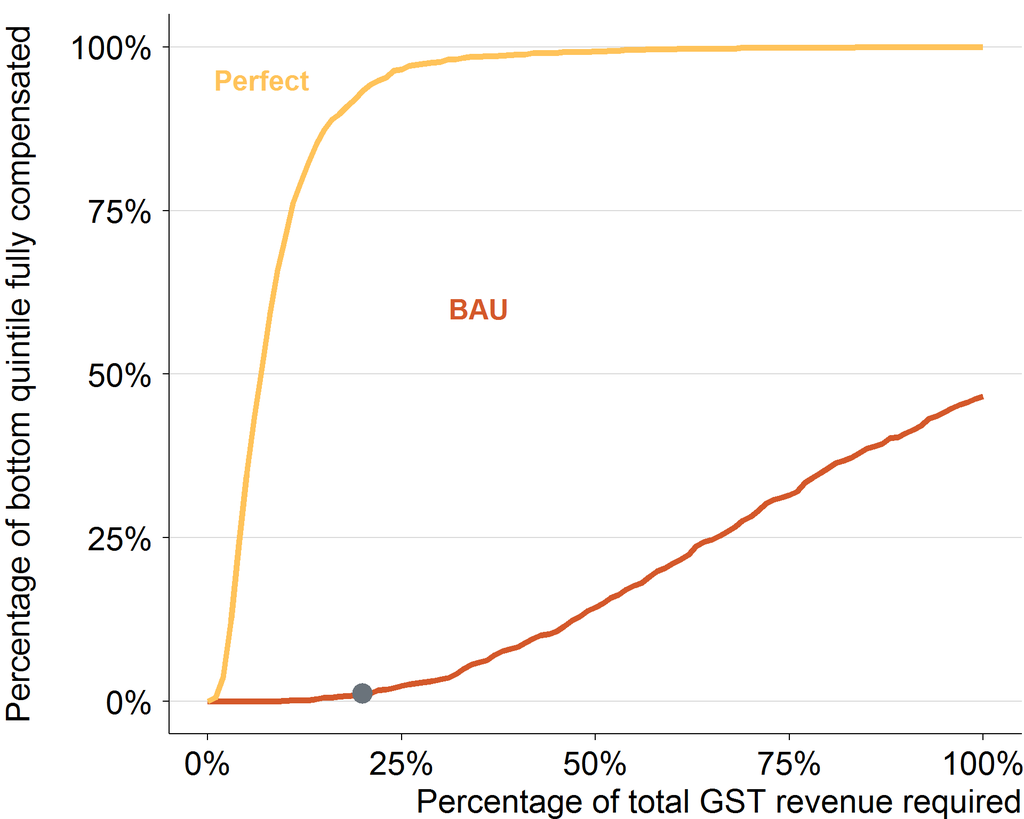

```r
perfect_and_imperfect <-
  bind_rows(ordinarily_targeted_efficacy.15pc, perfectly_targeted_efficacy.15pc, .id = "targeting")

perfect_and_imperfect %>%
  grplot(aes(x = percentage_revenue, y = percentage_compensated, color = targeting, group = targeting)) +
  geom_line() +
  theme(axis.title.y = element_text(angle = 90)) +
  scale_x_continuous("Percentage of total GST revenue required", label=scales::percent) +
  scale_y_continuous("Percentage of bottom quintile fully compensated\n", label=scales::percent) +
  annotate("text",
           x = c(0.07, 0.35),
           y = c(0.95, 0.6),
           label = c("Perfect", "BAU"),
           color = rev(gpal(2)),
           fontface = "bold",
           size = 7) +
  annotate("point",
           x = 0.2,
           y = ordinarily_targeted_efficacy.15pc[ordinarily_targeted_efficacy.15pc$percentage_revenue == 0.2]$percentage_compensated,
           size = 7,
           color = theGrey)
```

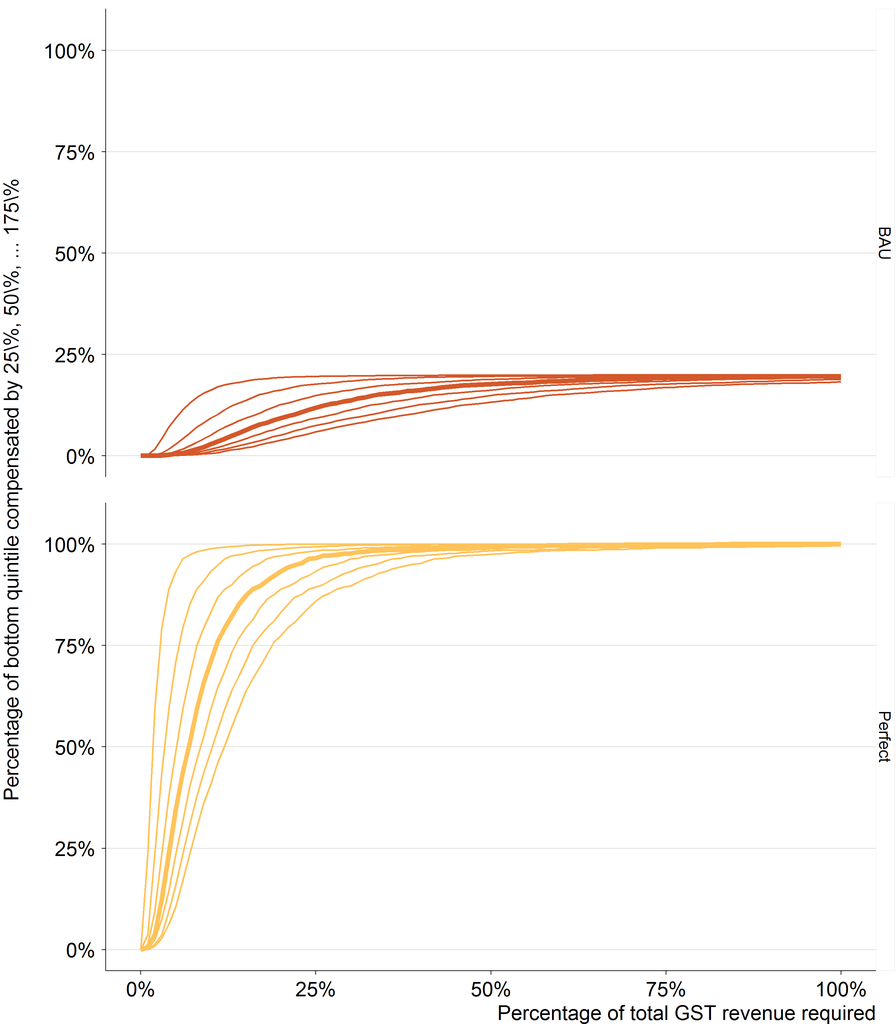

```r
perfect_and_imperfect_comp_adequacy <-
  bind_rows(ordinarily_targeted_efficacy_comp_adequacy.15pc, perfectly_targeted_efficacy_comp_adequacy.15pc, .id = "targeting") %>%
  mutate(targeting = ifelse(targeting == 1, "BAU", "Perfect"))

text_facet <-
  data.frame(targeting = factor(c("BAU", "Perfect")),
             percentage_revenue = c(0.07, 0.35),
             percentage_compensated = c(1.05, 0.6),
             comp_adequacy = c(0,0),
             alpha = c(0,0),
             size = c(0,0),
             linetype = c("A", "B"))

text_facet.bau <-
  data.frame(targeting = factor("BAU", levels =  c("BAU", "Perfect")),
             percentage_revenue = c(0.07),
             percentage_compensated = c(1.05),
             comp_adequacy = c(0),
             alpha = c(0),
             size = c(0),
             linetype = c("A"))

text_facet.perf <-
  filter(text_facet, targeting == "Perfect")

perfect_and_imperfect_comp_adequacy %>%
  mutate(alpha = ifelse(comp_adequacy == 1, 1, 1),
         size  = ifelse(comp_adequacy == 1, 2.5, 1.025),
         linetype = ifelse(comp_adequacy == 1, "A", "A")) %>%
  grplot(aes(x = percentage_revenue, y = percentage_compensated, color = targeting, group = interaction(targeting, comp_adequacy), alpha = alpha, size = size, linetype = linetype)) +
  geom_line() +
  theme(axis.title.y = element_text(angle = 90)) +
  scale_x_continuous("Percentage of total GST revenue required", label=scales::percent) +
  scale_y_continuous("Percentage of bottom quintile compensated by 25\\%, 50\\%, ... 175\\%\n", label=scales::percent) +
  scale_alpha_identity() +
  scale_size_identity() +
  geom_text(data = text_facet.bau,
            label = "BAU") +
  geom_text(data = text_facet.perf,
            label = "Perfect") +
  theme(panel.margin = unit(2, "lines")) +
  facet_grid(targeting ~ .)
```